# CASA0005 第二周：R、数据整理、连接与长宽表

按[官方第 2 章](https://andrewmaclachlan.github.io/CASA0005repo/introduction-to-r.html)顺序整理R、表格整理与长宽转换。打开课程 `casa0005.Rproj`，代码按顺序运行；Knit 从头计算普通分析块；安装、导出与可选联网分支单独执行。

来源：MacLachlan、Dennett、Dooley；[CC BY-SA 4.0](https://creativecommons.org/licenses/by-sa/4.0/)。中文整理与适配经 AI 辅助，见改编范围；源版本 `0b19a3339034e3bd3de1e8246559d453301f07eb`。

## 2.4 R 基础

使用课程项目与共用路径工具。

```r
helper <- c("tutorial-tools.R", "../tutorial-tools.R")
source(helper[file.exists(helper)][1])
gis_packages(c("tidyverse", "sf", "janitor", "tmap"))
library(tidyverse)
library(sf)
library(tmap)
root <- gis_root()
```

## 计算与赋值

运算遵循优先级；赋值保存当前结果，修改输入不会自动重算已有对象。

```r
getwd()
```

```
## [1] "[project]/week02"
```

```r
1 + 5
```

```
## [1] 6
```

```r
4 * 5^2
```

```
## [1] 100
```

```r
A <- 1
B <- 2
C <- A + B
C
```

```
## [1] 3
```

```r
ls()
```

```
## [1] "A"      "B"      "C"      "helper" "root"
```

```r
rm(A)
```

## 向量、表格与索引

`[行, 列]` 取子集；`$` 和 `[[ ]]` 取列向量。`rnorm()` 的结果随运行变化。

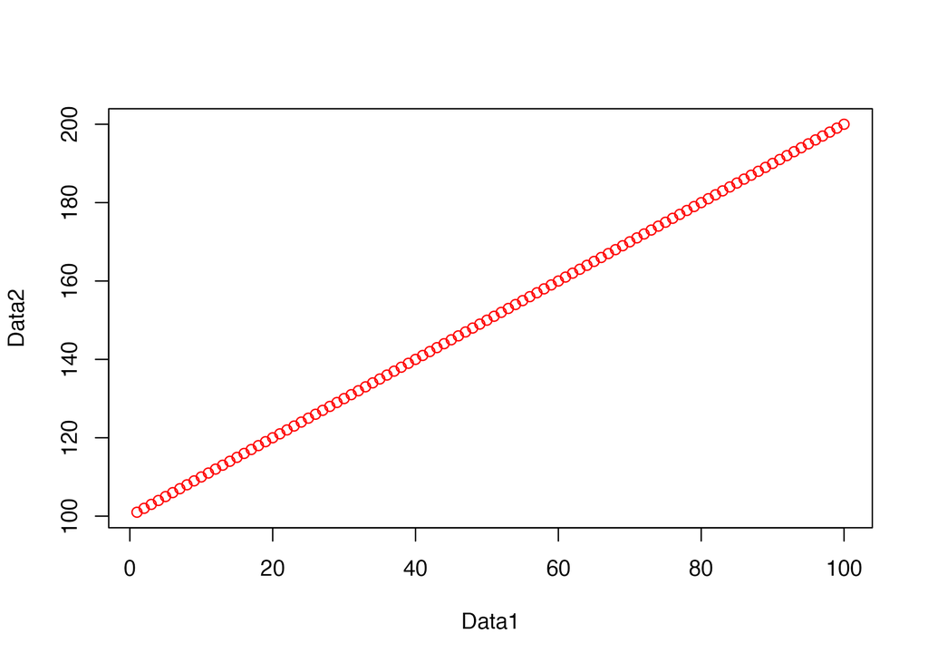

```r
Data1 <- c(1:100)
Data2 <- c(101:200)
plot(Data1, Data2, col = "red")
```

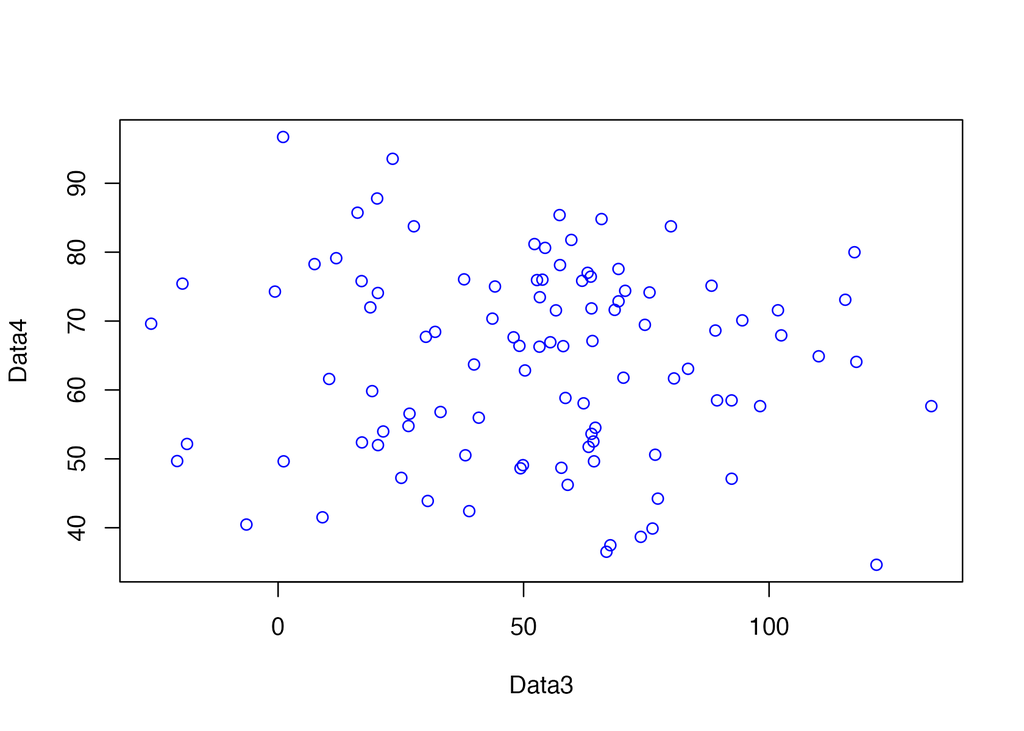

```r
Data3 <- rnorm(100, mean = 53, sd = 34)
Data4 <- rnorm(100, mean = 64, sd = 14)
plot(Data3, Data4, col = "blue")
```

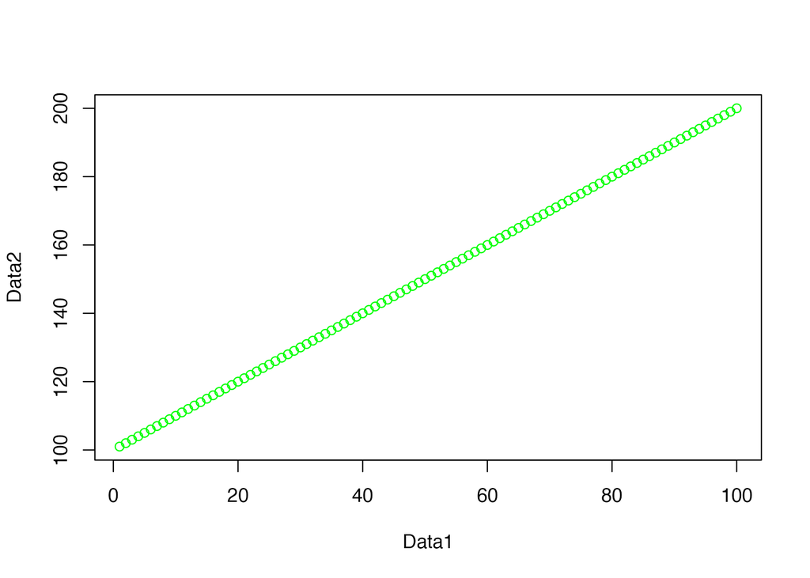

```r
df <- data.frame(Data1, Data2)
plot(df, col = "green")
```

```r
head(df)
```

```
##   Data1 Data2
## 1     1   101
## 2     2   102
## 3     3   103
## 4     4   104
## 5     5   105
## 6     6   106
```

```r
tail(df)
```

```
##     Data1 Data2
## 95     95   195
## 96     96   196
## 97     97   197
## 98     98   198
## 99     99   199
## 100   100   200
```

```r
df[1:10, 1]
```

```
##  [1]  1  2  3  4  5  6  7  8  9 10
```

```r
df[5:15, ]
```

```
##    Data1 Data2
## 5      5   105
## 6      6   106
## 7      7   107
## 8      8   108
## 9      9   109
## 10    10   110
## 11    11   111
## 12    12   112
## 13    13   113
## 14    14   114
## 15    15   115
```

```r
df[c(2, 3, 6), 2]
```

```
## [1] 102 103 106
```

```r
df[, 1]
```

```
##   [1]   1   2   3   4   5   6   7   8   9  10  11  12  13  14  15  16  17  18
##  [19]  19  20  21  22  23  24  25  26  27  28  29  30  31  32  33  34  35  36
##  [37]  37  38  39  40  41  42  43  44  45  46  47  48  49  50  51  52  53  54
##  [55]  55  56  57  58  59  60  61  62  63  64  65  66  67  68  69  70  71  72
##  [73]  73  74  75  76  77  78  79  80  81  82  83  84  85  86  87  88  89  90
##  [91]  91  92  93  94  95  96  97  98  99 100
```

```r
df <- dplyr::rename(df, column1 = Data1, column2 = Data2)
dplyr::select(df, column1)
```

```
##     column1
## 1         1
## 2         2
## 3         3
## 4         4
## 5         5
## 6         6
## 7         7
## 8         8
## 9         9
## 10       10
## 11       11
## 12       12
## 13       13
## 14       14
```

[output cut: 86 more lines]

```r
df$column1
```

```
##   [1]   1   2   3   4   5   6   7   8   9  10  11  12  13  14  15  16  17  18
##  [19]  19  20  21  22  23  24  25  26  27  28  29  30  31  32  33  34  35  36
##  [37]  37  38  39  40  41  42  43  44  45  46  47  48  49  50  51  52  53  54
##  [55]  55  56  57  58  59  60  61  62  63  64  65  66  67  68  69  70  71  72
##  [73]  73  74  75  76  77  78  79  80  81  82  83  84  85  86  87  88  89  90
##  [91]  91  92  93  94  95  96  97  98  99 100
```

```r
df[["column1"]]
```

```
##   [1]   1   2   3   4   5   6   7   8   9  10  11  12  13  14  15  16  17  18
##  [19]  19  20  21  22  23  24  25  26  27  28  29  30  31  32  33  34  35  36
##  [37]  37  38  39  40  41  42  43  44  45  46  47  48  49  50  51  52  53  54
##  [55]  55  56  57  58  59  60  61  62  63  64  65  66  67  68  69  70  71  72
##  [73]  73  74  75  76  77  78  79  80  81  82  83  84  85  86  87  88  89  90
##  [91]  91  92  93  94  95  96  97  98  99 100
```

## 2.5 数据读取与类型

Ward Profiles 使用 latin1；`problems()` 检查解析，NA 保持缺失含义。教材的 Excel 分支是在副本中清除 `#VALUE!`、`n/a` 后保存 CSV，主线采用下方 R 导入。

```r
ward_file <- gis_file("data/raw/london/attributes/ward-profiles-excel-version.csv")
LondonData <- readr::read_csv(ward_file, locale = locale(encoding = "latin1"),
                              na = c("", "NA", "n/a"), show_col_types = FALSE)
type_table <- tibble(variable = names(LondonData),
                     type = vapply(LondonData, function(x) paste(class(x), collapse = "/"), character(1)))
type_table
```

```
## # A tibble: 67 × 2
##    variable                           type
##    <chr>                              <chr>
##  1 Ward name                          character
##  2 Old code                           character
##  3 New code                           character
##  4 Population - 2015                  numeric
##  5 Children aged 0-15 - 2015          numeric
##  6 Working-age (16-64) - 2015         numeric
##  7 Older people aged 65+ - 2015       numeric
##  8 % All Children aged 0-15 - 2015    numeric
##  9 % All Working-age (16-64) - 2015   numeric
## 10 % All Older people aged 65+ - 2015 numeric
## # ℹ 57 more rows
```

```r
readr::problems(LondonData)
```

```
## # A tibble: 0 × 5
## # ℹ 5 variables: row <int>, col <int>, expected <chr>, actual <chr>, file <chr>
```

```r
names(LondonData)
```

```
##  [1] "Ward name"
##  [2] "Old code"
##  [3] "New code"
##  [4] "Population - 2015"
##  [5] "Children aged 0-15 - 2015"
##  [6] "Working-age (16-64) - 2015"
##  [7] "Older people aged 65+ - 2015"
##  [8] "% All Children aged 0-15 - 2015"
##  [9] "% All Working-age (16-64) - 2015"
## [10] "% All Older people aged 65+ - 2015"
## [11] "Mean Age - 2013"
## [12] "Median Age - 2013"
## [13] "Area - Square Kilometres"
## [14] "Population density (persons per sq km) - 2013"
## [15] "% BAME - 2011"
```

[output cut: 52 more lines]

```r
summary(LondonData)
```

```
##      Ward name        Old code        New code   Population - 2015
##  Length   :660   Length   :660   Length   :660   Min.   :    5300
##  N.unique :659   N.unique :659   N.unique :659   1st Qu.:   11700
##  N.blank  :  0   N.blank  :  0   N.blank  :  0   Median :   13800
##  Min.nchar:  5   Min.nchar:  1   Min.nchar:  9   Mean   :  121989
##  Max.nchar: 58   Max.nchar:  6   Max.nchar:  9   3rd Qu.:   16062
##                                                  Max.   :54613400
##
##  Children aged 0-15 - 2015 Working-age (16-64) - 2015
##  Min.   :     650          Min.   :    3050
##  1st Qu.:    2150          1st Qu.:    7788
##  Median :    2700          Median :    9600
##  Mean   :   23510          Mean   :   79260
##  3rd Qu.:    3400          3rd Qu.:   11200
##  Max.   :10335450          Max.   :34540350
##
##  Older people aged 65+ - 2015 % All Children aged 0-15 - 2015
##  Min.   :    600              Min.   : 6.50
##  1st Qu.:   1200              1st Qu.:17.70
##  Median :   1500              Median :19.80
##  Mean   :  19219              Mean   :19.79
##  3rd Qu.:   1900              3rd Qu.:22.02
##  Max.   :9737650              Max.   :32.70
##
##  % All Working-age (16-64) - 2015 % All Older people aged 65+ - 2015
##  Min.   :57.40                    Min.   : 3.7
##  1st Qu.:64.58                    1st Qu.: 8.5
##  Median :67.40                    Median :11.1
##  Mean   :68.42                    Mean   :11.8
##  3rd Qu.:71.92                    3rd Qu.:14.4
##  Max.   :83.90                    Max.   :24.3
##
##  Mean Age - 2013 Median Age - 2013 Area - Square Kilometres
##  Min.   :28.70   Min.   :27.00     Min.   :     0.40
##  1st Qu.:33.80   1st Qu.:32.00     1st Qu.:     1.30
##  Median :35.50   Median :34.00     Median :     1.95
##  Mean   :35.96   Mean   :34.46     Mean   :   204.61
##  3rd Qu.:38.00   3rd Qu.:37.00     3rd Qu.:     3.20
##  Max.   :44.30   Max.   :46.00     Max.   :130259.70
##
```

[output cut: 313 more lines]

```
##  Min.   :0.2000            Min.   :1.300
##  1st Qu.:0.6000            1st Qu.:2.700
##  Median :0.8000            Median :3.400
##  Mean   :0.8411            Mean   :3.779
##  3rd Qu.:1.1000            3rd Qu.:4.650
##  Max.   :1.7000            Max.   :8.000
##                            NAs    :1
##  % travel by bicycle to work - 2011 Turnout at Mayoral election - 2012
##  Min.   : 0.200                     Min.   :19.30
##  1st Qu.: 1.300                     1st Qu.:31.10
##  Median : 2.800                     Median :34.40
##  Mean   : 3.919                     Mean   :34.39
##  3rd Qu.: 5.800                     3rd Qu.:37.80
##  Max.   :19.100                     Max.   :51.70
##                                     NAs    :1
```

## 筛选与寿命指标

按 E09 地区代码筛选 borough，只去整行完全重复记录。男女寿命简单平均后与历史基准 81.16 年比较；不是人口加权指标。

```r
LondonBoroughs <- LondonData %>%
  filter(stringr::str_detect(`New code`, "^E09")) %>%
  distinct() %>%
  dplyr::rename(Borough = `Ward name`) %>%
  janitor::clean_names()
gis_unique(LondonBoroughs, "new_code")
LondonBoroughs %>% dplyr::select(contains("expectancy"), borough)
```

```
## # A tibble: 33 × 3
##    male_life_expectancy_2009_13 female_life_expectancy_2009_13 borough
##                           <dbl>                          <dbl> <chr>
##  1                         84.3                           88.6 City of London
##  2                         77.7                           82.4 Barking and Dage…
##  3                         81.9                           85   Barnet
##  4                         80.3                           84.3 Bexley
##  5                         80                             84.9 Brent
##  6                         81.3                           84.9 Bromley
##  7                         81.1                           86   Camden
##  8                         80                             83.5 Croydon
##  9                         79.9                           84.3 Ealing
## 10                         80.6                           84.3 Enfield
## # ℹ 23 more rows
```

```r
Life_expectancy <- LondonBoroughs %>%
  mutate(averagelifeexpectancy = (female_life_expectancy_2009_13 + male_life_expectancy_2009_13) / 2,
         normalisedlifeexpectancy = averagelifeexpectancy / mean(averagelifeexpectancy, na.rm = TRUE)) %>%
  dplyr::select(new_code, borough, averagelifeexpectancy, normalisedlifeexpectancy) %>%
  arrange(desc(normalisedlifeexpectancy))
slice_head(Life_expectancy, n = 5)
```

```
## # A tibble: 5 × 4
##   new_code  borough                averagelifeexpectancy normalisedlifeexpecta…¹
##   <chr>     <chr>                                  <dbl>                   <dbl>
## 1 E09000001 City of London                          86.4                    1.05
## 2 E09000020 Kensington and Chelsea                  84.4                    1.03
## 3 E09000015 Harrow                                  84.2                    1.02
## 4 E09000027 Richmond upon Thames                    83.9                    1.02
## 5 E09000033 Westminster                             83.8                    1.02
## # ℹ abbreviated name: ¹normalisedlifeexpectancy
```

```r
slice_tail(Life_expectancy, n = 5)
```

```
## # A tibble: 5 × 4
##   new_code  borough              averagelifeexpectancy normalisedlifeexpectancy
##   <chr>     <chr>                                <dbl>                    <dbl>
## 1 E09000011 Greenwich                             80.8                    0.983
## 2 E09000012 Hackney                               80.7                    0.982
## 3 E09000025 Newham                                80.6                    0.980
## 4 E09000002 Barking and Dagenham                  80.1                    0.974
## 5 E09000030 Tower Hamlets                         80.0                    0.974
```

```r
Life_expectancy2 <- Life_expectancy %>%
  mutate(UKdiff = averagelifeexpectancy - 81.16,
         UKcompare = case_when(is.na(UKdiff) ~ NA_character_,
                               UKdiff > 0 ~ "above UK average", TRUE ~ "at or below UK average"))
Life_expectancy2 %>% group_by(UKcompare) %>%
  summarise(count = n(), range = max(UKdiff) - min(UKdiff), mean = mean(UKdiff), .groups = "drop")
```

```
## # A tibble: 2 × 4
##   UKcompare              count range   mean
##   <chr>                  <int> <dbl>  <dbl>
## 1 above UK average          25 5.25   1.52
## 2 at or below UK average     8 0.900 -0.572
```

```r
Life_expectancy3 <- Life_expectancy2 %>%
  mutate(across(where(is.numeric), ~round(.x, 3)),
         UKdiff_rounded = round(UKdiff, 0)) %>%
  count(UKcompare, UKdiff_rounded)
Life_expectancy3
```

```
## # A tibble: 7 × 3
##   UKcompare              UKdiff_rounded     n
##   <chr>                           <dbl> <int>
## 1 above UK average                    0     4
## 2 above UK average                    1    12
## 3 above UK average                    2     4
## 4 above UK average                    3     4
## 5 above UK average                    5     1
## 6 at or below UK average             -1     3
## 7 at or below UK average              0     5
```

```r
Life_expectancy4 <- Life_expectancy2
```

## 属性散点图

横轴为男性预期寿命，纵轴为儿童肥胖率；图形描述关联。

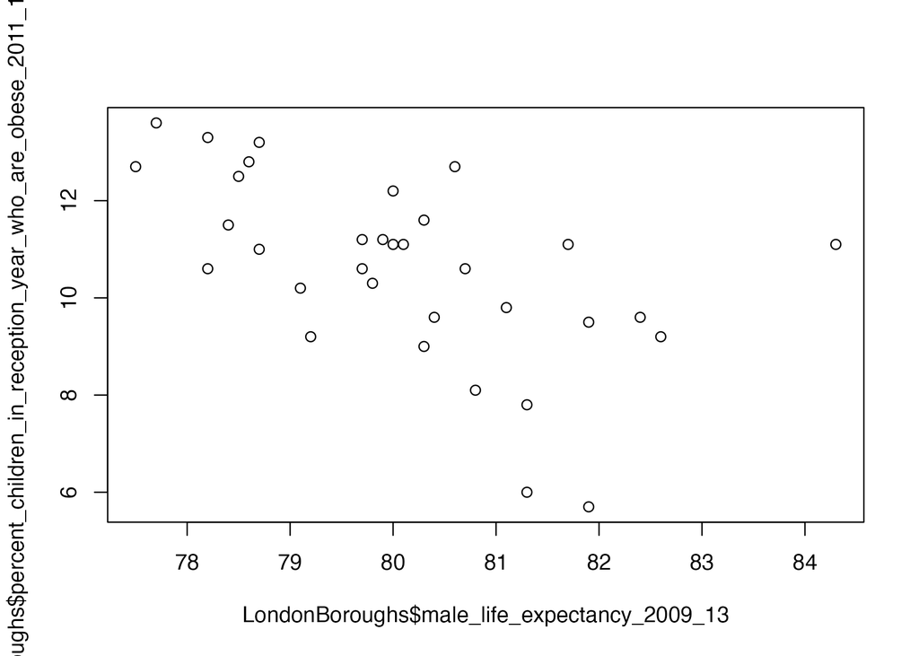

```r
plot(LondonBoroughs$male_life_expectancy_2009_13,
     LondonBoroughs$percent_children_in_reception_year_who_are_obese_2011_12_to_2013_14)
```

## 边界与属性连接

代码键保持一地区一行；`left_join` 保留伦敦边界，`inner_join` 保留两侧匹配地区。

```r
EW <- st_read(gis_file("data/raw/london/boundaries/lad_dec_2015_gb_bfc/LAD_Dec_2015_FCB_GB.shp"), quiet = TRUE) %>%
  janitor::clean_names()
LondonMap <- EW %>% filter(str_detect(lad15cd, "^E09"))
gis_unique(LondonMap, "lad15cd")

dplyr::anti_join(st_drop_geometry(LondonMap), LondonBoroughs, by = c("lad15cd" = "new_code"))
```

```
## [1] objectid   lad15cd    lad15nm    lad15nmw   global_id  shape_leng shape_area
## <0 rows> (or 0-length row.names)
```

```r
BoroughDataMap <- left_join(LondonMap, LondonBoroughs,
                            by = c("lad15cd" = "new_code"), relationship = "one-to-one")
Life_expectancy4map <- inner_join(EW, Life_expectancy4,
                                 by = c("lad15cd" = "new_code"), relationship = "one-to-one")
stopifnot(nrow(BoroughDataMap) == nrow(LondonMap))
```

## JSA 静态地图

JSA 字段是领取率；与数量区分。

```r
tmap_mode("plot")
```

```
## ℹ tmap modes "plot" - "view"
## ℹ toggle with `tmap::ttm()`
```

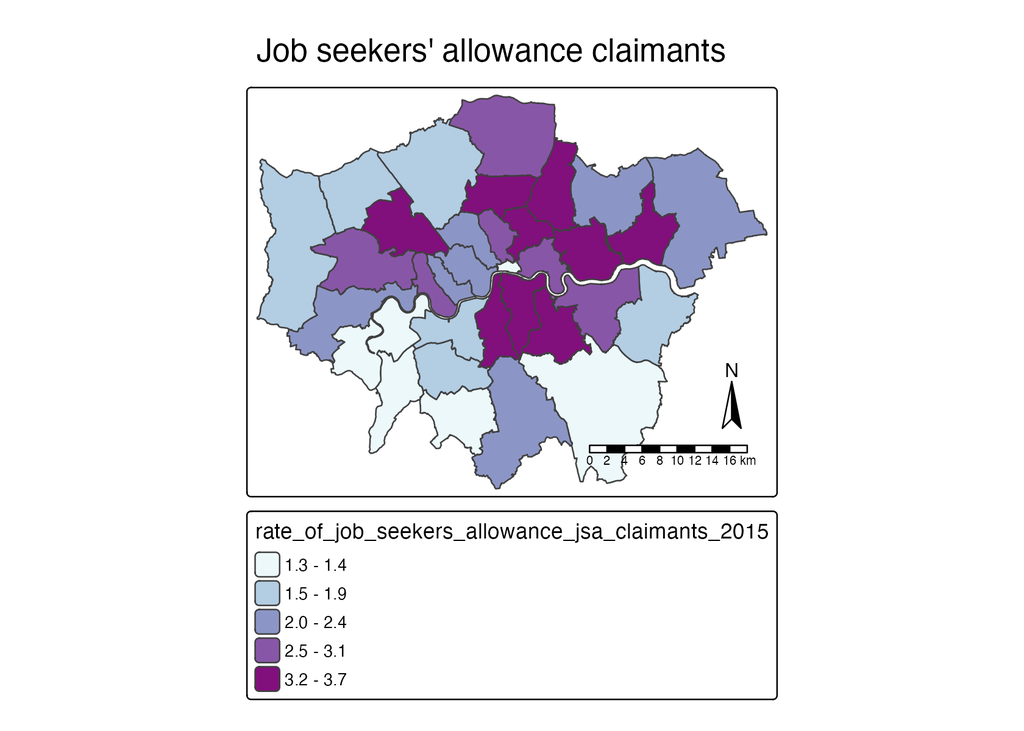

```r
jsa <- "rate_of_job_seekers_allowance_jsa_claimants_2015"
gis_columns(BoroughDataMap, jsa)
jsa_map <- tm_shape(BoroughDataMap) +
  tm_polygons(fill = jsa, fill.scale = tm_scale_intervals(style = "jenks", values = "brewer.bu_pu")) +
  tm_title("Job seekers' allowance claimants") + tm_compass() + tm_scalebar()
jsa_map
```

## 栅格底图分支

需要网络、OpenStreetMap 包及相应 Java 依赖；失败时可使用下一块交互底图。

```r
gis_packages("tmaptools")
tmaplondon <- tmaptools::read_osm(st_bbox(BoroughDataMap), type = "esri", zoom = NULL)
tmap_mode("plot")
tm_shape(tmaplondon) + tm_rgb() +
  tm_shape(BoroughDataMap) +
  tm_polygons(fill = jsa, fill_alpha = 0.5,
              fill.scale = tm_scale_intervals(style = "jenks", values = "brewer.bu_pu")) +
  tm_compass() + tm_scalebar() + tm_title("Job seekers' allowance claimants")
```

## 交互地图

转为 EPSG:4326，并叠加 OpenStreetMap 在线底图。

```r
tmap_mode("view")
```

```
## ℹ tmap modes "plot" - "view"
```

```r
tm_shape(st_transform(BoroughDataMap, 4326)) +
  tm_polygons(fill = jsa, fill_alpha = 0.5) + tm_basemap("OpenStreetMap")
```

[interactive chart not shown]

## 寿命差值图

`UKdiff` 单位为寿命年数差，正值高于教材基准。

```r
tmap_mode("plot")
```

```
## ℹ tmap modes "plot" - "view"
```

```r
tm_shape(Life_expectancy4map) +
  tm_polygons(fill = "UKdiff", fill.scale = tm_scale_intervals(values = "brewer.rd_bu")) +
  tm_title("Life expectancy difference from tutorial UK baseline")
```

```
## [`tm_scale_intervals()`] Variable(s) "fill" contains positive and negative
## values, so midpoint is set to 0. Set midpoint = NA to show the full range of
## visual values.
```

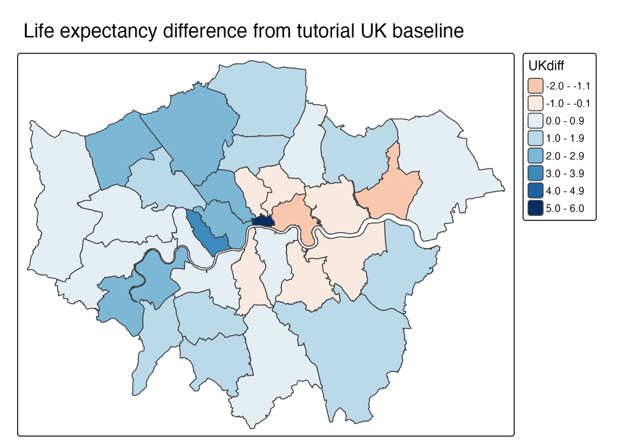

## 2.6 长宽表转换

使用 `fly-tipping-long.csv`，不使用第一周中文透视宽表。数值含千位逗号和 `:` 缺失占位；`fly_parsing_problems` 在整理前保存。长表一行是地区×年度×指标，八种指标不互相混称。

```r
fly_file <- gis_file("data/raw/london/attributes/fly-tipping-long.csv")
measures <- c("total_incidents", "total_action_taken", "warning_letters", "fixed_penalty_notices",
              "statutory_notices", "formal_cautions", "injunctions", "prosecutions")
fly_types <- readr::cols(code = col_character(), area = col_character(), year = col_character(),
  total_incidents = col_number(), total_action_taken = col_number(), warning_letters = col_number(),
  fixed_penalty_notices = col_number(), statutory_notices = col_number(), formal_cautions = col_number(),
  injunctions = col_number(), prosecutions = col_number())
flytipping <- read_csv(fly_file, col_types = fly_types)
fly_parsing_problems <- readr::problems(flytipping)
fly_parsing_problems
```

```
## # A tibble: 12 × 5
##      row   col expected actual file
##    <int> <int> <chr>    <chr>  <chr>
##  1   141     4 a number :      /Users/aries/Documents/GitHub/casa/05-geographic…
##  2   166     4 a number :      /Users/aries/Documents/GitHub/casa/05-geographic…
##  3   192     4 a number :      /Users/aries/Documents/GitHub/casa/05-geographic…
##  4   258     4 a number :      /Users/aries/Documents/GitHub/casa/05-geographic…
##  5   343     4 a number :      /Users/aries/Documents/GitHub/casa/05-geographic…
##  6   343     5 a number :      /Users/aries/Documents/GitHub/casa/05-geographic…
##  7   343     6 a number :      /Users/aries/Documents/GitHub/casa/05-geographic…
##  8   343     7 a number :      /Users/aries/Documents/GitHub/casa/05-geographic…
##  9   343     8 a number :      /Users/aries/Documents/GitHub/casa/05-geographic…
## 10   343     9 a number :      /Users/aries/Documents/GitHub/casa/05-geographic…
## 11   343    10 a number :      /Users/aries/Documents/GitHub/casa/05-geographic…
## 12   343    11 a number :      /Users/aries/Documents/GitHub/casa/05-geographic…
```

```r
names(flytipping)
```

```
##  [1] "code"                  "area"                  "year"
##  [4] "total_incidents"       "total_action_taken"    "warning_letters"
##  [7] "fixed_penalty_notices" "statutory_notices"     "formal_cautions"
## [10] "injunctions"           "prosecutions"
```

```r
gis_columns(flytipping, c("code", "area", "year", measures))
flytipping <- flytipping %>% mutate(year = as.character(year))
stopifnot(!anyDuplicated(flytipping[c("code", "year")]))
flytipping_long <- flytipping %>% pivot_longer(all_of(measures), names_to = "tipping_type", values_to = "count")
flytipping_wide <- flytipping_long %>%
  pivot_wider(id_cols = c(code, area), names_from = c(year, tipping_type), names_sep = "_", values_from = count)
widefly <- flytipping %>% dplyr::select(code, area, year, total_incidents) %>%
  pivot_wider(names_from = year, values_from = total_incidents)
stopifnot(nrow(flytipping_long) == nrow(flytipping) * length(measures))
head(flytipping_long)
```

```
## # A tibble: 6 × 5
##   code      area           year    tipping_type          count
##   <chr>     <chr>          <chr>   <chr>                 <dbl>
## 1 E09000001 City of London 2011-12 total_incidents         527
## 2 E09000001 City of London 2011-12 total_action_taken      563
## 3 E09000001 City of London 2011-12 warning_letters         149
## 4 E09000001 City of London 2011-12 fixed_penalty_notices   182
## 5 E09000001 City of London 2011-12 statutory_notices         3
## 6 E09000001 City of London 2011-12 formal_cautions           0
```

```r
head(flytipping_wide)
```

```
## # A tibble: 6 × 114
##   code      area                 2011-12_total_incident…¹ 2011-12_total_action…²
##   <chr>     <chr>                                   <dbl>                  <dbl>
## 1 E09000001 City of London                            527                    563
## 2 E09000002 Barking and Dagenham                     3665                   2687
## 3 E09000003 Barnet                                   1450                   2356
## 4 E09000004 Bexley Council                            980                    505
## 5 E09000005 Brent                                    7272                   6713
## 6 E09000006 Bromley                                  2222                    306
## # ℹ abbreviated names: ¹`2011-12_total_incidents`,
## #   ²`2011-12_total_action_taken`
## # ℹ 110 more variables: `2011-12_warning_letters` <dbl>,
## #   `2011-12_fixed_penalty_notices` <dbl>, `2011-12_statutory_notices` <dbl>,
## #   `2011-12_formal_cautions` <dbl>, `2011-12_injunctions` <dbl>,
## #   `2011-12_prosecutions` <dbl>, `2012-13_total_incidents` <dbl>,
## #   `2012-13_total_action_taken` <dbl>, `2012-13_warning_letters` <dbl>, …
```

## Homework 与阅读

华盛顿州 Science 县级人数加权比较见 homework.Rmd；现成百分比采用 tested 分母，作业按 expected 重算并报告 DAT 排除。

## 资料链接

- [官方第2章](https://andrewmaclachlan.github.io/CASA0005repo/introduction-to-r.html)
- [Week 2 quiz Word文档](https://moodle.ucl.ac.uk/mod/resource/view.php?id=9275869)